# World Population

Estimates of world population range back as far as 1 million BC,although early estimates are sparse and can vary wildly [^1]. The raw data from nine such studies is below.

```python
# Display the raw data as a "data frame"
import pandas as pd
df=pd.read_csv("population.csv",keep_default_na=False)
df
```

|  | Year | Average | Deevey | McEvedy and Jones 1978 | Durand Low | Durand High | Clark | Biraben | Blaxter | UN | Kremer |
| --- | --- | --- | --- | --- | --- | --- | --- | --- | --- | --- | --- |
| 0 | -1000000 | 0.125000 | 0.125 |  |  |  |  |  |  |  |  |
| 1 | -300000 | 1.000000 | 1 |  |  |  |  |  |  |  |  |
| 2 | -25000 | 3.340000 | 3.34 |  |  |  |  |  |  |  |  |
| 3 | -10000 | 4.000000 |  | 4 |  |  |  |  |  |  |  |
| 4 | -8000 | 5.320000 | 5.32 |  |  |  |  |  |  |  |  |
| 5 | -5000 | 22.500000 |  | 5 |  |  |  |  | 40 |  |  |
| 6 | -4000 | 46.750000 | 86.5 | 7 |  |  |  |  |  |  |  |
| 7 | -3000 | 14.000000 |  | 14 |  |  |  |  |  |  |  |
| 8 | -2000 | 27.000000 |  | 27 |  |  |  |  |  |  |  |
| 9 | -1600 | 70.000000 |  |  |  |  |  |  | 70 |  |  |
| 10 | -1000 | 50.000000 |  | 50 |  |  |  |  |  |  |  |
| 11 | -800 | 100.000000 |  |  |  |  |  |  | 100 |  |  |
| 12 | -500 | 100.000000 |  | 100 |  |  |  |  |  |  |  |
| 13 | -400 | 157.500000 |  |  |  |  |  | 153 | 162 |  |  |
| 14 | -200 | 202.000000 |  | 150 |  |  |  | 225 | 231 |  |  |
| 15 | 1 | 235.000000 | 133 | 170 | 270 | 330 |  | 252 | 255 |  |  |
| 16 | 14 | 256.000000 |  |  |  |  | 256 |  |  |  |  |
| 17 | 200 | 234.333333 |  | 190 |  |  |  | 257 | 256 |  |  |
| 18 | 350 | 254.000000 |  |  |  |  | 254 |  |  |  |  |
| 19 | 400 | 200.666667 |  | 190 |  |  |  | 206 | 206 |  |  |
| 20 | 500 | 198.500000 |  | 190 |  |  |  | 207 |  |  |  |
| 21 | 600 | 212.750000 |  | 200 |  |  | 237 | 208 | 206 |  |  |
| 22 | 700 | 207.666667 |  | 210 |  |  |  | 206 | 207 |  |  |
| 23 | 800 | 232.250000 |  | 220 |  |  | 261 | 224 | 224 |  |  |
| 24 | 900 | 229.333333 |  | 240 |  |  |  | 222 | 226 |  |  |
| 25 | 1000 | 278.666667 |  | 265 | 275 | 345 | 280 | 253 | 254 |  |  |
| 26 | 1100 | 306.666667 |  | 320 |  |  |  | 299 | 301 |  |  |
| 27 | 1200 | 386.000000 |  | 360 |  |  | 384 | 400 | 400 |  |  |
| 28 | 1250 | 417.000000 |  |  |  |  |  | 417 |  |  |  |
| 29 | 1300 | 407.666667 |  | 360 |  |  |  | 431 | 432 |  |  |
| 30 | 1340 | 410.000000 |  |  |  |  | 378 | 442 |  |  |  |
| 31 | 1400 | 366.333333 |  | 350 |  |  |  | 375 | 374 |  |  |
| 32 | 1500 | 458.833333 |  | 425 | 440 | 540 | 427 | 461 | 460 |  |  |
| 33 | 1600 | 550.000000 |  | 545 |  |  | 498 | 578 | 579 |  |  |
| 34 | 1650 | 535.333333 | 545 | 545 |  |  | 516 |  |  |  |  |
| 35 | 1700 | 652.500000 |  | 610 |  |  | 641 | 680 | 679 |  |  |
| 36 | 1750 | 751.428571 | 728 | 720 | 735 | 805 | 731 | 771 | 770 |  |  |
| 37 | 1800 | 920.800000 | 906 | 900 |  |  | 890 | 954 | 954 |  |  |
| 38 | 1850 | 1218.000000 |  | 1200 |  |  | 1190 | 1241 | 1241 |  |  |
| 39 | 1875 | 1325.000000 |  | 1325 |  |  |  |  |  |  |  |
| 40 | 1900 | 1647.142857 | 1610 | 1625 | 1650 | 1710 | 1668 | 1634 | 1633 |  |  |
| 41 | 1920 | 1813.000000 |  |  |  |  |  |  |  |  | 1813 |
| 42 | 1925 | 2000.000000 |  | 2000 |  |  |  |  |  |  |  |
| 43 | 1930 | 1987.000000 |  |  |  |  |  |  |  |  | 1987 |
| 44 | 1940 | 2213.000000 |  |  |  |  |  |  |  |  | 2213 |
| 45 | 1950 | 2495.000000 | 2400 |  |  |  |  | 2530 | 2513 | 2516 | 2516 |
| 46 | 1955 | 2626.000000 |  | 2500 |  |  |  |  |  | 2752 |  |
| 47 | 1960 | 3019.500000 |  |  |  |  |  |  |  | 3020 | 3019 |
| 48 | 1965 | 3336.000000 |  |  |  |  |  |  |  | 3336 |  |
| 49 | 1970 | 3676.000000 |  |  |  |  |  | 3637 |  | 3698 | 3693 |
| 50 | 1975 | 3957.250000 |  | 3900 | 3900 | 3950 |  |  |  | 4079 |  |
| 51 | 1980 | 4437.666667 |  |  |  |  |  |  | 4415 | 4448 | 4450 |
| 52 | 1985 | 4851.000000 |  |  |  |  |  |  |  | 4851 |  |
| 53 | 1990 | 5312.500000 |  |  |  |  |  |  |  | 5292 | 5333 |

A naive plotting of the data looks like this.

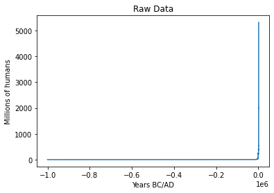

```python
#Tell matplotlib to render in the notebook
%matplotlib inline
import matplotlib.pyplot as plt
plt.title('Raw Data')
plt.xlabel('Years BC/AD')
plt.ylabel('Millions of humans')
plt.plot(df.Year,df.Average)
```

which might lead you to believe that world population is exploding at a near infinite rate, and that we will all be standing shoulder to shoulder momentarily. Fortunately, that's not the case.

Summarizing the one million or so years before 1700 as "world population gradually grew to somewhere between 600 and 700 million", and excluding it, produces a graph like this...

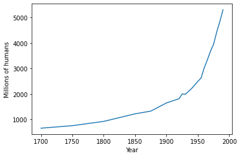

```python
plt.xlabel('Year')
plt.ylabel('Millions of humans')
plt.plot(df.Year.where(df.Year >= 1700),df.Average)
```

Better at this granularity, but it still appears as an exponential growth curve. Could Robert Malthus have been right, and mass starvation is right around the corner? No, but you won't get the answer from this data. In reality, global population, although still going up, is decelerating, and could be more accurately described as screeching to a halt as less prosperous nations modernize and have less children [^2]. The details and analysis of this are beyond the scope of this notebook, which is really just a sample topic for me to play with Jupyter Notebooks, but I'd recommend a read of The Rational Optimist by Matt Ridley if you wish to explore.